# Exploring a Data Frame

zewahyu

## Introduction

Data frames are the most common structure of storing data in R. Today’s lab highlights some common functions in R we would like to use to explore a data frame before conducting any profound data analysis.

## Loading the Data

The dataset we are going to explore contains customer default records for a credit card company.

### Method 1 - read.table

We begin by loading the data from a .csv file (csv is short for comma-separated values) using the `read.table()` function. This function reads a file in table format and creates a **data frame** from it, with cases corresponding to lines and variables to fields in the file.

```r
default_data<-read.table("Default.csv", header = TRUE, sep = ",")
```

The first argument supplied to `read.table()` is the pathname to the .csv file. It can be a path relative to the current **working directory** (we can use the `getwd()` command to find the current working directory), which is, by default, the directory where this R Markdown file locates. If the directory doesn’t contain the data file, we have to type the whole pathname (the **absolute path**) or to change the working directory by using setwd().

```r
getwd()
```

```
## [1] "C:/Users/LENOVO/Downloads/ISOM3390/github/lab/lab2"
```

```r
#Windows
#setwd("C:/Users/imjosh/Desktop")
#Mac
#setwd("/Users/Name/Desktop")
default_data<-read.table("Default.csv", header = TRUE, sep = ",")
#Difference between read.csv and read.table
```

```r
default_data<-read.table("C:/Users/imjosh/Desktop/Default.csv", header = TRUE, sep = ",") #Absolute path
```

The `header` argument is used to specify whether the file contains the names of the variables as its first line. If the data has names for each of the columns on the top row, set `header = TRUE`. The `sep` argument is used to specify the field separator character. The default one is white space.

The funtion will convert columns to logical, integer, numeric, complex vectors or factors as appropriate automatically. You need to set `stringsAsFactors = T` if you need to convert character to factor ).

### Method 2 - read.csv

```r
#setwd("C:/Users/imjosh/Desktop")
#default_data2<-read.csv("Default.csv")
```

### Method 3 - File Choose

```r
#default_data3<- read.csv(file.choose())
```

Once the data is loaded, we assign the data frame to a variable for later reference.

## Exploring the Data Frame

Before we do anything else, it is important to understand the structure of the data and that of any objects derived from it.

```r
typeof(default_data)
```

```
## [1] "list"
```

```r
length(default_data)
```

```
## [1] 4
```

```r
class(default_data)
```

```
## [1] "data.frame"
```

```r
str(default_data)
```

```
## 'data.frame':    10000 obs. of  4 variables:
##  $ default: chr  "No" "No" "No" "No" ...
##  $ student: chr  "No" "Yes" "No" "No" ...
##  $ balance: num  730 817 1074 529 786 ...
##  $ income : num  44362 12106 31767 35704 38463 ...
```

The `dim()` function can be used to obtain the dimensions of the data frame (number of rows and number of columns). The `nrow()` and `ncol()` functions can be used to get the number of rows and number of columns, respectively.

```r
dim(default_data)
```

```
## [1] 10000     4
```

```r
nrow(default_data)
```

```
## [1] 10000
```

```r
ncol(default_data)
```

```
## [1] 4
```

Provide your code that uses `dim()` in conjunction with a subsetting operation instead of `nrow()` to get the number of rows:

### Task 1

```r
dim(default_data)[1]
```

```
## [1] 10000
```

These are commands for obtaining an intuitive idea of what the data look like without revealing the entire data set, which could have millions of rows and thousands of columns. The `head()` function is used to obtain the first *n* observations and the `tail()` function to obtain the last *n* observations.

```r
head(default_data)           # extract the first few (default to 6) rows
```

```
##   default student   balance    income
## 1      No      No  729.5265 44361.625
## 2      No     Yes  817.1804 12106.135
## 3      No      No 1073.5492 31767.139
## 4      No      No  529.2506 35704.494
## 5      No      No  785.6559 38463.496
## 6      No     Yes  919.5885  7491.559
```

```r
head(default_data, n = 10)
```

```
##    default student   balance    income
## 1       No      No  729.5265 44361.625
## 2       No     Yes  817.1804 12106.135
## 3       No      No 1073.5492 31767.139
## 4       No      No  529.2506 35704.494
## 5       No      No  785.6559 38463.496
## 6       No     Yes  919.5885  7491.559
## 7       No      No  825.5133 24905.227
## 8       No     Yes  808.6675 17600.451
## 9       No      No 1161.0578 37468.529
## 10      No      No    0.0000 29275.268
```

Provide your code to display the last 5 rows:

### Task 2

```r
tail(default_data, n = 5)
```

```
##       default student   balance   income
## 9996       No      No  711.5550 52992.38
## 9997       No      No  757.9629 19660.72
## 9998       No      No  845.4120 58636.16
## 9999       No      No 1569.0090 36669.11
## 10000      No     Yes  200.9222 16862.95
```

`summary()` can be used to produce summaries of a data object. When it is applied to a **data frame**, this function is essentially applied to each column, and the results for all columns are shown together.

- minimum
- 1st quartile
- median
- 3rd quartile
- maximum.

If there are any missing values (denoted by `NA`), it would also provide a count for them. In this example, there are no missing values, so there is no display for the number of `NA`’s.

```r
summary(default_data)
default_data$balance
default_data[["balance"]]
typeof(default_data["balance"])
typeof(default_data[["balance"]])
typeof(default_data[,"balance"])
```

[output not shown]

For a categorical variable, R didn’t stored them as a factor, we need to change it to factor which returns the levels and the number of cases in each level.

There are two way we can change it to factor

```r
is.factor(default_data$default)
default_data$default<-factor(default_data$default)
summary(default_data)
```

[output not shown]

```r
default_data<-read.table("Default.csv", header = TRUE, sep = ",", stringsAsFactors = T)
summary(default_data)
```

```
##  default    student       balance           income
##  No :9667   No :7056   Min.   :   0.0   Min.   :  772
##  Yes: 333   Yes:2944   1st Qu.: 481.7   1st Qu.:21340
##                        Median : 823.6   Median :34553
##                        Mean   : 835.4   Mean   :33517
##                        3rd Qu.:1166.3   3rd Qu.:43808
##                        Max.   :2654.3   Max.   :73554
```

### Table

We can create a table from the data by using table()

```r
table(default_data$student)
```

[output not shown]

Provide the code to cross-tabulate **default** and **student** to see how defaults vary between students and non-students.

### Task3

```r
table(default_data$default,default_data$student, dnn=c("default","student"))
```

```
##        student
## default   No  Yes
##     No  6850 2817
##     Yes  206  127
```

### Level

The assignment form of the `levels()` function can be used to change the labels of a factor. Provide the code that converts **default** to take logical values, with `No` mapped to `FALSE` and `Yes` to `TRUE`.

### Task 4

```r
levels(default_data[["default"]]) <- c(F, T) #mapped to logical values
head(default_data)
```

```
##   default student   balance    income
## 1   FALSE      No  729.5265 44361.625
## 2   FALSE     Yes  817.1804 12106.135
## 3   FALSE      No 1073.5492 31767.139
## 4   FALSE      No  529.2506 35704.494
## 5   FALSE      No  785.6559 38463.496
## 6   FALSE     Yes  919.5885  7491.559
```

## Subsetting and Querying the Data Frame

As mention in the previous part, we can get all value in the column from the data frame by using different method such as “$” or “[[]]”. However, sometimes we dont need entire column, we just need some row, what we can do is to use “[row, column]”

```r
default_data$default
default_data[["default"]]
default_data[1,1] #return the value in row1,column1
default_data[1,"default"] # you can also use name
default_data[1,] #return entire row if you do not specify which column
default_data[default_data$income>30000,] #return only the row which the income higher than 30000
```

[output not shown]

We can produce two pairs of boxplots to graphically depict how numeric values of **balance** and **income** differ between non-defaulters and defaulters through their quartiles.

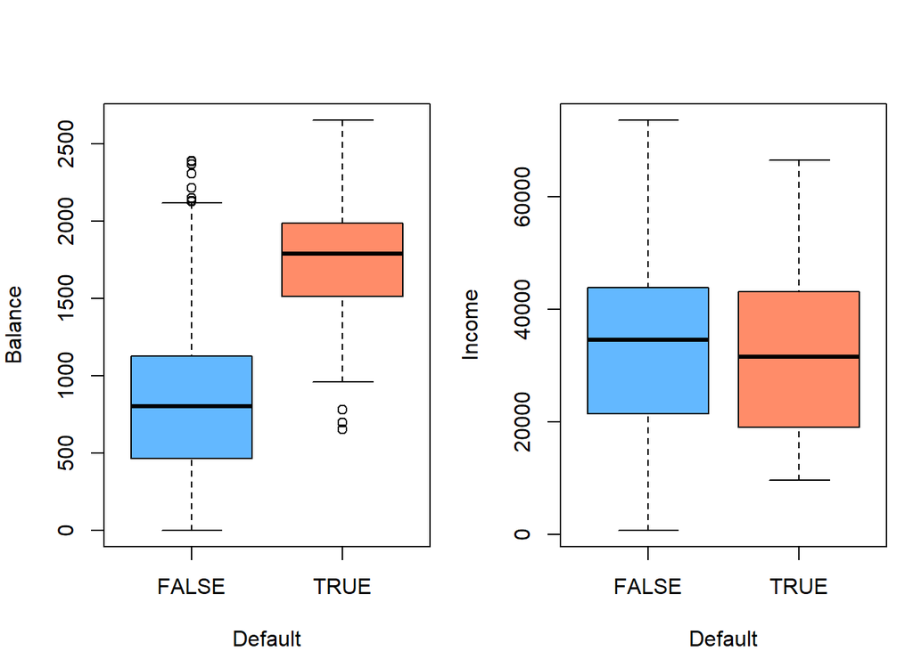

Provide your code to calculate the medians corresponding to the four boxes (Hint: `median()`)

### Task 5

```r
median(default_data[default_data$default==F, c(3)])
```

```
## [1] 802.8571
```

```r
median(default_data[default_data$default==T, c(3)])
```

```
## [1] 1789.093
```

```r
median(default_data[default_data$default==F, c(4)])
```

```
## [1] 34589.49
```

```r
median(default_data[default_data$default==T, c(4)])
```

```
## [1] 31515.34
```